# ONR VR Task Performance

## Overview

Thank you for participating in our study (we hope you had fun!). The purpose of this document is to 1) explain the two tasks that you played in virtual reality (VR); and 2) share your performance for the three testing conditions (Day1 = Rest; Day2 = Exercise; Day3 = No Sleep). Information from your Day 0 is not present since that was considered a practice day.

```
The following document is intended solely for ID # 42
```

————————————————————————————————————————————————————————————————-I

## Go/No-Go

The Go/No-Go task was the first game you played in VR. This task required you to hit certain shapes that were seen often (Go trials) and to avoid hitting shapes that were presented rarely (No-Go trials). This task is a measure of **inhibition ability** since better performance on No-Go trials indicates greater ability to inhibit a habituated response. The graphs below show overall performance for both Go and No-Go trials for all three testing days (left) and the reaction times for correct Go trials (right). Smaller numbers for reaction time indicate quicker speed in hitting the Go trials, which is a good thing.

————————————————————————————————————————————————————————————————-I

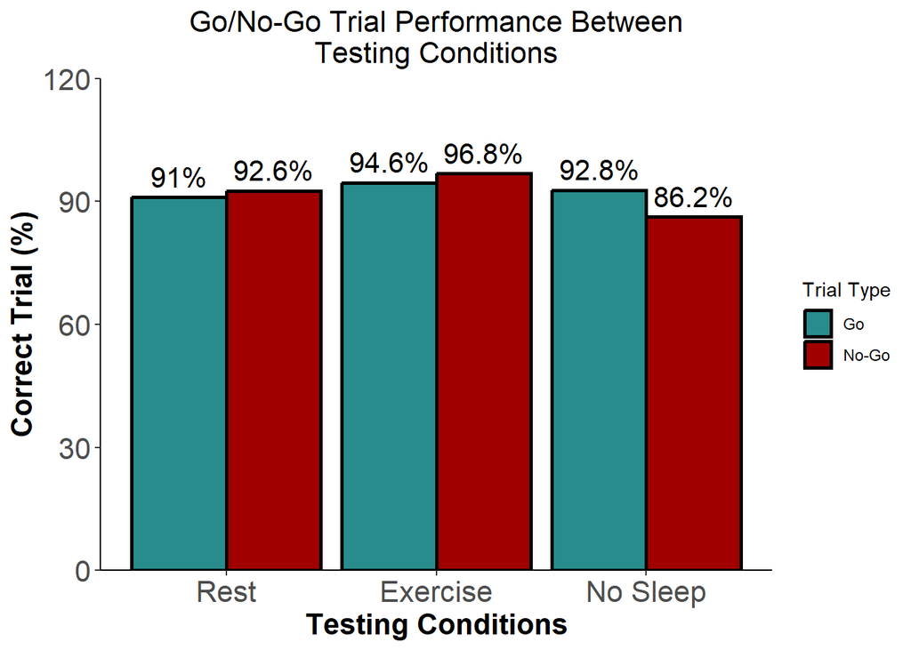

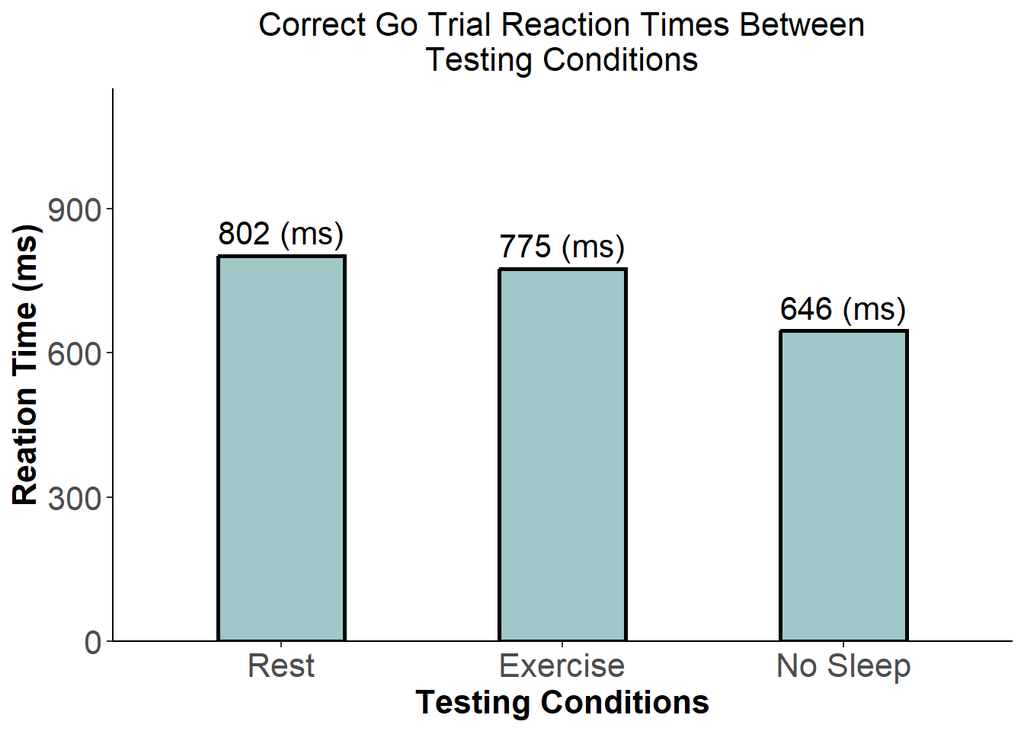

————————————————————————————————————————————————————————————————-I

## NBack

The Nback was the second game you played in VR and is considered to be harder than the Go/No-Go. Our version of this task required you to hit a shape if it matched a shape that you saw two trials back (target). This type of task measures your **working memory ability**. Higher performance on target trials showed you remembered a shape correctly and higher performance on non-target trials indicated a greater ability to not misremember presented stimuli. The graphs below respectively show performance for these trial types for all three testing days (left) and reaction times for correct target trials (right).

————————————————————————————————————————————————————————————————-I

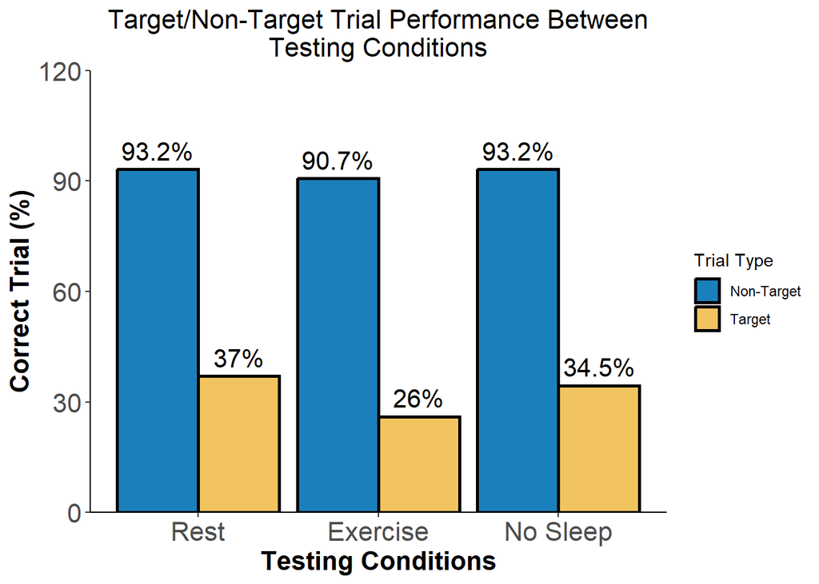

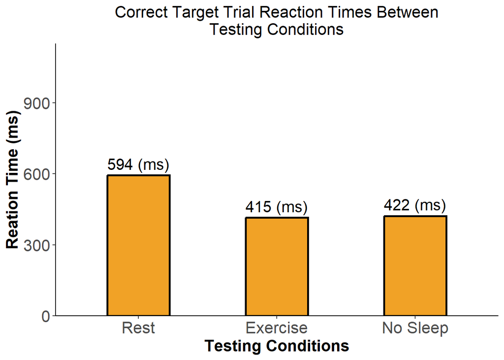

————————————————————————————————————————————————————————————————-I